# Diabetes Report

Ahmed Galaa

2024-08-21

Hello, this is a report of an analysis of a dataset provided by [Avery Smith](https://www.linkedin.com/in/averyjsmith?lipi=urn%3Ali%3Apage%3Ad_flagship3_profile_view_base_contact_details%3BgnZLkuicRnKf0rYb7Il3XA%3D%3D) who modified this [dataset](https://archive.ics.uci.edu/dataset/296/diabetes+130-us+hospitals+for+years+1999-2008) from [UCI Machine Learning Repository](https://archive.ics.uci.edu/) to match educational purposes.

The analysis has been made on several steps by me, for example:

1. Used PostgreSQL to query the data.
2. Used Microsoft PowerBI to build a dashboard shows the wanted tasks.
3. Used R markdown combined with the local PostgreSQL server to make this report and R language to make the visualizations in it.

And of course I’m going to break it down along with this report.

## The Analysis

### Adding the data to PostgreSQL local database.

1. A database was created in the local host of pgAdmin4, I gave it a name (diabetes).
2. I then had to add these tables to the database, so that I created the tables with a very smart way to save some time from creating the tables and specifting each data type. With the assistance of AI I copied the column names and the first few rows from the CSV files, and then I prompted the LLM to give me the SQL code that creates this table, then I took the whole code, pasted it in postgres, run it, and here we have our tables created fast and easy with te power of AI.
3. To write my queries I always perefere [VS Code](https://code.visualstudio.com/) as my favorite tool to write whatever a code, so I connected it with postgreSQL and then started quering the data.
4. This dasshboard whas created using Microsoft PowerBI according to the data resulted from the SQL queries.

[figure not shown]

IMPORTANT NOTE: for better understanding of the codes I recomment taking a look at [this folder](https://drive.google.com/drive/folders/1XQj_w_PNTHe2F-LplpVI5fmIG59NVt-C?usp=drive_link) which has all the files if the analysis.

## The Tasks

### 1. What is the distribution of time spent in the hospital?

#### CREATE VIEW

For this I created a “view” first, this step saves me some time in the next queries when I need to call the same query once again.

```r
CREATE VIEW pt_condition AS
    SELECT
        time_in_hospital AS time_spent,
        COUNT(*) AS frequency_of_duration,
        CASE
            WHEN time_in_hospital > 7 THEN 'Acute Symptoms' ELSE 'Non-acute Symptoms'
            END AS patient_condition
    FROM diabetic_data
    GROUP BY time_in_hospital ORDER BY time_in_hospital;
```

If we take a look at the results, it shows that the periods patients stay in the hospital are in a range between 1 and 14 days, we categorized these periods according to the acuity of the patients as the patient who stays for a period longer than 7 days is considered a patient who has experienced acute symptoms.

When it’s called, we get this result:

```r
data1 <- dbGetQuery(con, "SELECT * FROM pt_condition;")
head(data1, 14)
```

```
##    time_spent frequency_of_duration  patient_condition
## 1           1                 14208 Non-acute Symptoms
## 2           2                 17224 Non-acute Symptoms
## 3           3                 17756 Non-acute Symptoms
## 4           4                 13924 Non-acute Symptoms
## 5           5                  9966 Non-acute Symptoms
## 6           6                  7539 Non-acute Symptoms
## 7           7                  5859 Non-acute Symptoms
## 8           8                  4391     Acute Symptoms
## 9           9                  3002     Acute Symptoms
## 10         10                  2342     Acute Symptoms
## 11         11                  1855     Acute Symptoms
## 12         12                  1448     Acute Symptoms
## 13         13                  1210     Acute Symptoms
## 14         14                  1042     Acute Symptoms
```

And by calculating the number of patients that have experienced acute symptoms the result is:

```r
head(dbGetQuery(con, "SELECT SUM(frequency_of_duration) AS patients_with_acute_symptoms
FROM pt_condition
WHERE patient_condition = 'Acute Symptoms';"))
```

```
##   patients_with_acute_symptoms
## 1                        15290
```

We also got something to highlight which is our success stories showing those who have admitted with an emergency situation but stayed for a period less than the average stay time shows as follows:

```r
head(dbGetQuery(con, "WITH avg_stay AS (
    SELECT AVG(time_in_hospital) AS avg_time_hospital FROM diabetic_data
)
SELECT patient_nbr, race, gender, age
FROM diabetic_data, avg_stay
WHERE admission_type_id = 1 AND time_in_hospital < avg_stay.avg_time_hospital;"))
```

```
##   patient_nbr            race gender     age
## 1    55629189       Caucasian Female [10-20)
## 2    86047875 AfricanAmerican Female [20-30)
## 3    82442376       Caucasian   Male [30-40)
## 4    42519267       Caucasian   Male [40-50)
## 5    92519352 AfricanAmerican   Male [50-60)
## 6   108662661       Caucasian Female [50-60)
```

### 2. Make a list of medical specialties with an average procedure count above 2.5 and total procedure count above 50

#### GROUP BY, HAVING

According to the analysis, this query shows the top medical specialties that match the criteria provided earlier. Here I didn’t use count function as it will count the rows for how many time this medical specialty got a procedure, so as long as num_procedures cells may have values greater than 1 we should calculate the total number of procedures per specialty.

```r
data2 <- dbGetQuery(con,"SELECT
    medical_specialty,
    ROUND(AVG(num_procedures),2) AS avg_procedurs_count,
    SUM(num_procedures) AS total_procedurs_count
FROM diabetic_data
GROUP BY medical_specialty
HAVING
    AVG(num_procedures) > 2.5 AND
    SUM(num_procedures) > 50;")
head(data2, 8)
```

```
##                      medical_specialty avg_procedurs_count
## 1                           Cardiology                2.70
## 2 Obsterics&Gynecology-GynecologicOnco                3.60
## 3                          Radiologist                3.24
## 4                            Radiology                2.53
## 5      Surgery-Cardiovascular/Thoracic                3.25
## 6                     Surgery-Thoracic                3.50
## 7                     Surgery-Vascular                2.57
##   total_procedurs_count
## 1                 14474
## 2                    90
## 3                  3696
## 4                   134
## 5                  2116
## 6                   382
## 7                  1370
```

### 3. What is the average number of lab procedures broken down by race?

#### ggplot2

```r
head(dbGetQuery(con, "SELECT
    race,
    ROUND(AVG(num_lab_procedures),2) AS avg_lab_procedures
FROM diabetic_data
GROUP BY race;"))
```

```
##              race avg_lab_procedures
## 1        Hispanic              42.79
## 2 AfricanAmerican              44.09
## 3           Asian              41.21
## 4           Other              43.44
## 5               ?              44.10
## 6       Caucasian              42.83
```

For a better understanding of the analysis we can create a simple box plot using [ggplot2](https://ggplot2.tidyverse.org/), the medians of the races are pretty close to each others as well as the average ranges, so it show that there’s no relationship.

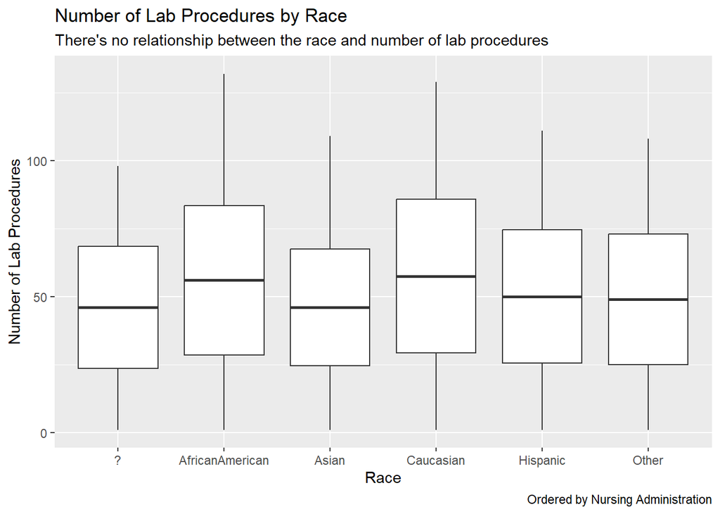

```r
data3 <- (dbGetQuery(con, "SELECT
    race,
    num_lab_procedures
FROM diabetic_data
GROUP BY race, num_lab_procedures;"))
ggplot(data = data3, mapping = aes(x = race, y = num_lab_procedures)) +
  geom_boxplot()+
  labs(title = "Number of Lab Procedures by Race",
       subtitle =  "There's no relationship between the race and number of lab procedures",
       caption = "Ordered by Nursing Administration",
       x = "Race", y = "Number of Lab Procedures"
       )
```

### 4. Find the relationship between number of lab procedures and time spent in the hospital. Categorize the number of lab procedures into three categories (few, average and many).

#### Temporary table, STDDEV

The secret behind this analysis is calculating the standard deviation(s); which is how far the values are from the mean, the purpose behind this calculation is that we want to get the average range for the number of lab procedures.

#### Average Range = [(mean - s),(mean + s)]

So that I created a query with more details as follows:

```r
head(dbGetQuery(con, "WITH avg_range AS(
    SELECT
    ROUND(AVG(num_lab_procedures),0) - ROUND(STDDEV(num_lab_procedures),0) AS min_avg,
    ROUND(AVG(num_lab_procedures),0) + ROUND(STDDEV(num_lab_procedures),0) AS max_avg,
    MAX(num_lab_procedures) AS max_lab_procedures,
    MIN(num_lab_procedures) AS min_lab_procedures
FROM diabetic_data
)
SELECT
    CONCAT(min_lab_procedures, ' to ', (min_avg - 1)) AS few,
    CONCAT(min_avg, ' to ', max_avg) AS average,
    CONCAT((max_avg + 1), ' to ', max_lab_procedures) AS many
FROM avg_range;
"))
```

```
##       few  average      many
## 1 1 to 22 23 to 63 64 to 132
```

And finally got the desired results

```r
head(dbGetQuery(con, "WITH avg_range AS(
    SELECT
    ROUND(AVG(num_lab_procedures),0) - ROUND(STDDEV(num_lab_procedures),0) AS min_avg,
    ROUND(AVG(num_lab_procedures),0) + ROUND(STDDEV(num_lab_procedures),0) AS max_avg,
    MAX(num_lab_procedures) AS max_lab_procedures,
    MIN(num_lab_procedures) AS min_lab_procedures
FROM diabetic_data
),
rate AS(
SELECT
    time_in_hospital AS time_spent,
    num_lab_procedures,
    CASE
        WHEN num_lab_procedures BETWEEN min_lab_procedures AND  (avg_range.min_avg - 1)THEN 'Few'
        WHEN num_lab_procedures BETWEEN avg_range.min_avg AND avg_range.max_avg THEN 'Average'
        ELSE 'Many'
    END AS procedures_rate
FROM diabetic_data, avg_range
)
SELECT
    procedures_rate,
    ROUND(AVG(time_spent), 2) AS avg_duration
FROM rate
GROUP BY procedures_rate ORDER BY avg_duration;"))
```

```
##   procedures_rate avg_duration
## 1             Few         3.22
## 2         Average         4.27
## 3            Many         6.25
```

### 5. Create a list of all patient numbers who are African Americans or have “Up” metformin.

#### WHERE OR

One of the simplest ways for filtering data in SQL is using WHERE combined with OR as follows in the next query:

```r
head(dbGetQuery(con, "SELECT patient_nbr FROM diabetic_data WHERE race = 'AfricanAmerican' OR metformin = 'Up';"))
```

```
##   patient_nbr
## 1    86047875
## 2    89869032
## 3    77391171
## 4    49726791
## 5    86328819
## 6    92519352
```

### 5. A summary of the top 50 patients, their medications and lab procedures.

#### CONCAT, CASE WHEN

And for the final task, it was asked to show the top 50 patients with medications and number of lab procedures, I used CONCAT to make the summary in one cell and by identifying the gender using CASE I made each sentence match with the gender of each patient mentioned in the list.

The quert was as follows:

```r
head(dbGetQuery(con, "SELECT
    CONCAT(
        (CASE WHEN gender = 'Male' THEN 'Mr. ' ELSE 'Mrs. ' END),
        patient_nbr, ' ',
        (CASE WHEN readmitted = 'NO' THEN 'has not readmitted. ' ELSE 'has readmitted. ' END),
        (CASE WHEN gender = 'Male' THEN 'He had ' ELSE 'She had ' END),
        num_medications, ' medications and ', num_lab_procedures, ' lab procedures.'
    ) AS admission_summary
FROM diabetic_data
ORDER BY num_medications DESC, num_lab_procedures DESC
LIMIT 50;"))
```

```
##                                                                 admission_summary
## 1       Mr. 24189597 has readmitted. He had 81 medications and 57 lab procedures.
## 2   Mr. 25112691 has not readmitted. He had 79 medications and 57 lab procedures.
## 3   Mr. 43503210 has not readmitted. He had 75 medications and 76 lab procedures.
## 4 Mrs. 24526629 has not readmitted. She had 75 medications and 61 lab procedures.
## 5   Mr. 25450911 has not readmitted. He had 74 medications and 62 lab procedures.
## 6       Mr. 42147990 has readmitted. He had 72 medications and 85 lab procedures.
```

## Conclusion

This report was made in an Rmd file by combining SQL with R and was also visualized in a dashboard using Microsoft PowerBI. This analysis has been made by Ahmed Galaa and was published in the LinkedIn profile at 20/8/2024. The same analysis has been performed earlier by [Rachel Lambert Miller](https://www.linkedin.com/in/rachel-lambert-miller?lipi=urn%3Ali%3Apage%3Ad_flagship3_profile_view_base_contact_details%3Bt0ge6hTnTp%2BA8w9GYjbUpw%3D%3D) and was published on her profile too. Thanks to [Avery Smith](https://www.linkedin.com/in/averyjsmith?lipi=urn%3Ali%3Apage%3Ad_flagship3_profile_view_base_contact_details%3BgnZLkuicRnKf0rYb7Il3XA%3D%3D) who has modified this [dataset](https://archive.ics.uci.edu/dataset/296/diabetes+130-us+hospitals+for+years+1999-2008) from [UCI Machine Learning Repository](https://archive.ics.uci.edu/) to match healthcare data analysis educational purpose.